# CIW Math refresher

Tina Rozsos

VU Amsterdam

October 15, 2025

## Math and stats refresher

### Overall goal

- Revise the math & stats concepts you need for the *Choices, Inequality, and Welfare* course
- Focus is on
  - intuitive understanding of concepts
  - ability to read and use math notation and graphical representations

### Plan for today

- solve and discuss exercises
- questions from self-test, then other topics you want to discuss

These slides complement the math self-test on [Desmos](https://student.desmos.com/?prepopulateCode=jzn6eu) and the [math review handout](https://shochguertel.github.io/mathminor/)

## Graphing functions

1. Consider the function $f(x) = 2x-1$
2. Goal: plot the values $f(x)$ takes for different values of $x$
3. Horizontal axis: $x$, vertical axis: $f(x)$
4. For example, for $x=0$, $f(0) = 2*0-1 = -1$
5. For $x=1$, $f(1) = 2*1-1 = 1$
6. Looking at the function, we can tell it’s linear – if $x$ increases by 1, $f(x)$ always increases by 2
7. So we can take two points and draw a straight line through them

## Graphing functions

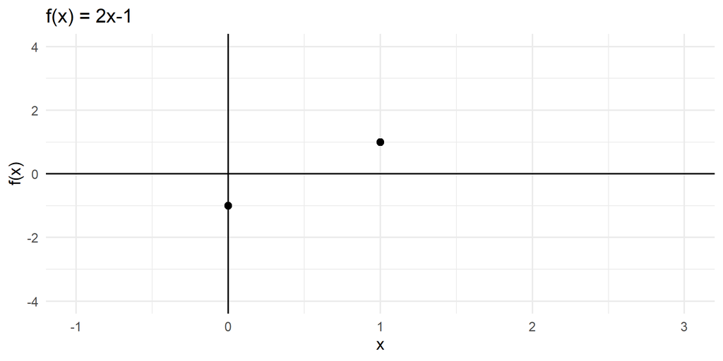

## Graphing functions

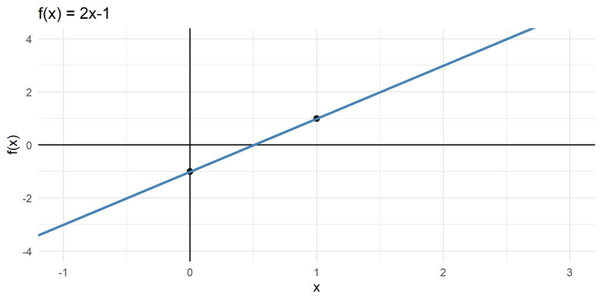

## Graphing functions (quadratic)

1. Example: $f(x) = (x-2)^2+3$
2. Quadratic functions are drawn as parabolas
3. To draw the function, find the vertex, and decide if it is a minimum or maximum
4. Finding the vertex:
   1. given $f(x) = a(x-h)^2+k$, the vertex is at $(h,k)$
   2. or calculate the derivative and set it to 0:
      1. given $f(x) = ax^2+bx+c$, $f'(x)=2ax+b$
      2. $2ax+b=0$ gives the $x$-coordinate of the vertex
      3. use the original $f(x)$ to find the $y$-coordinate
5. The sign of the $x^2$ term tells you if the parabola opens up (+) or down (-)
6. Calculating some more points to each side of the vertex helps to draw the parabola, e.g. for $x=0$, $f(0) = (0-2)^2+3 = 7$

## Graphing functions (quadratic)

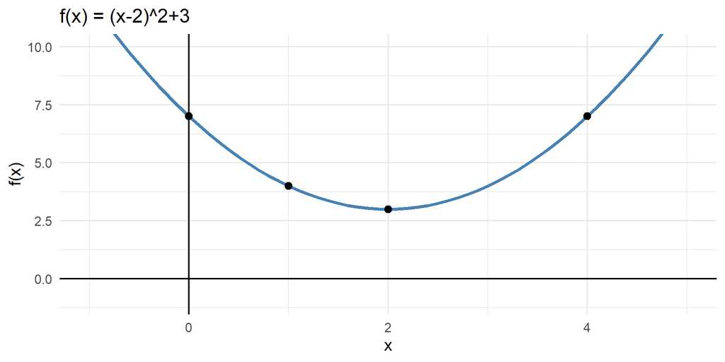

## Convexity and concavity

1. A function is *convex* if it lies on or below the line connecting any two points on the function
2. A function is *concave* if it lies on or above the line connecting any two points on the function
3. A function is *strictly convex (concave)* if it lies strictly below (above) the line connecting any two points on the function

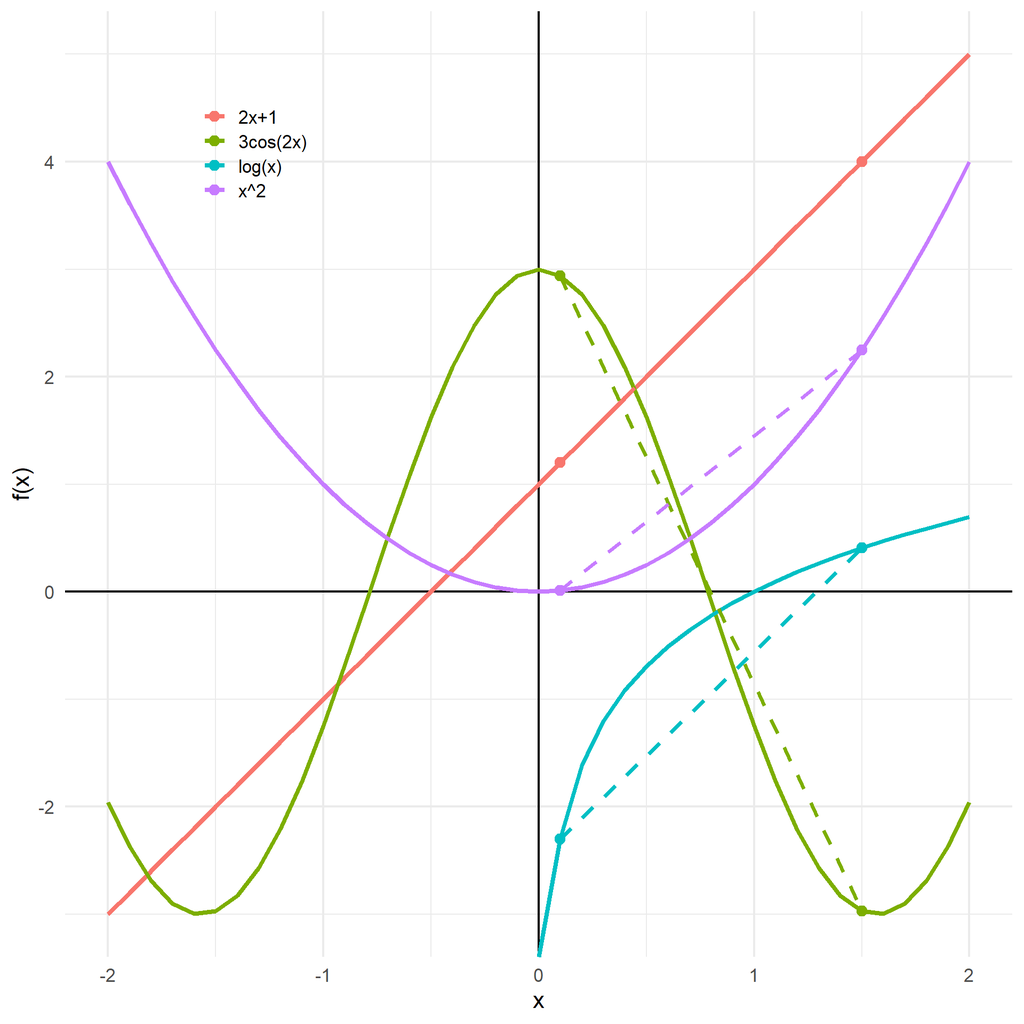

## Distributions

1. A distribution describes how likely different values of a variable are
2. A probability distribution function (pdf) gives the probability of each value
3. The cumulative distribution function (cdf) gives the probability of a value being less than or equal to a certain value

## Distributions

Consider the data:

```
(1, 1, 3, 4, 5, 5, 5, 6, 9, 10)
```

Plot the distribution of the data:

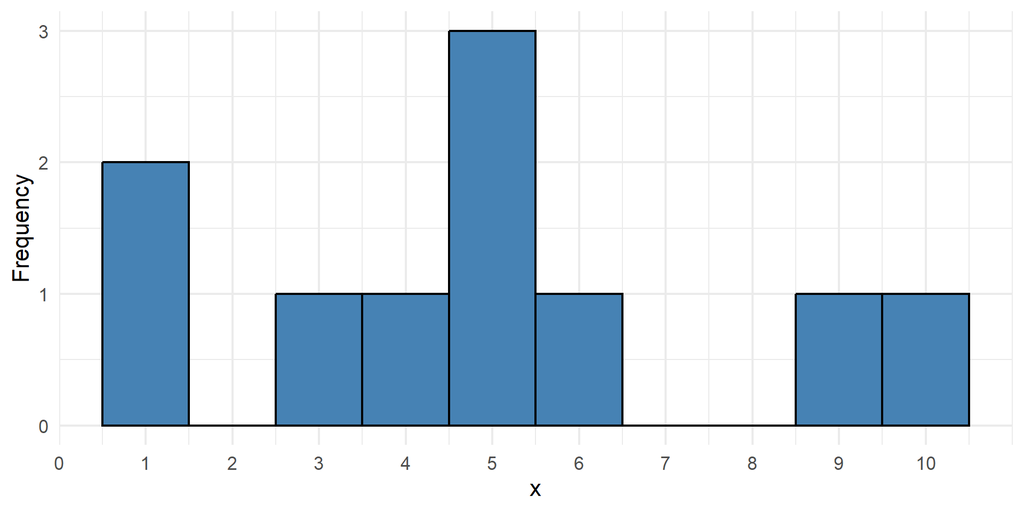

## Distributions

Consider the data:

```
(1, 1, 3, 4, 5, 5, 5, 6, 9, 10)
```

Rescale the frequencies to get a probability distribution:

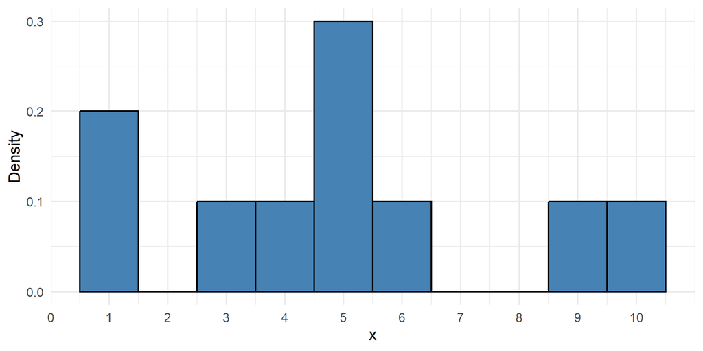

## Distributions

Consider the data, assuming it comes from a continuous distribution (i.e. any value is possible):

```
(1, 1, 3, 4, 5, 5, 5, 6, 9, 10)
```

Smooth out the histogram to get a density plot:

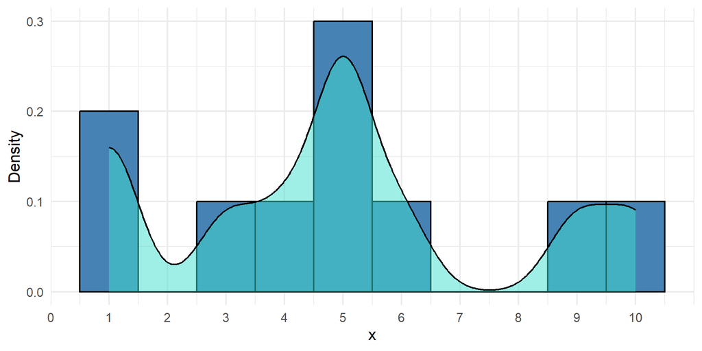

## Distributions

Consider the data, assuming it comes from a continuous distribution (i.e. any value is possible):

```
(1, 1, 3, 4, 5, 5, 5, 6, 9, 10)
```

The area of the density plot is 1, meaning that the probability of the variable taking any value within the full range is 1:

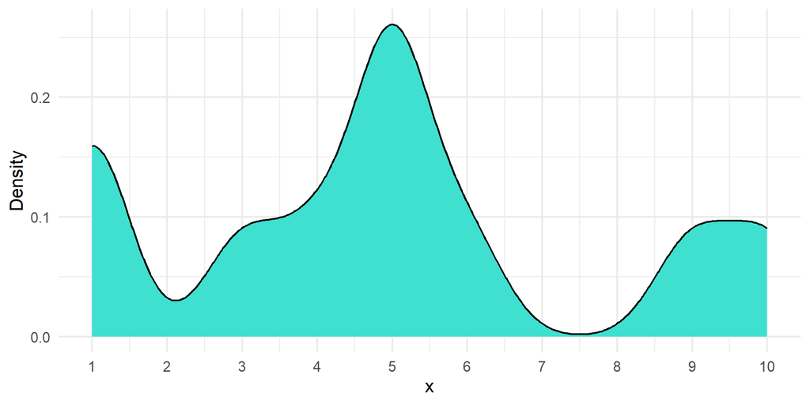

## Distributions

At each value of $x$, the CDF gives the area under the density curve to the left of $x$.

Using the discrete example from above, adding up the area of the histogram bars up to $x$ gives the height of the CDF at each value of $x$:

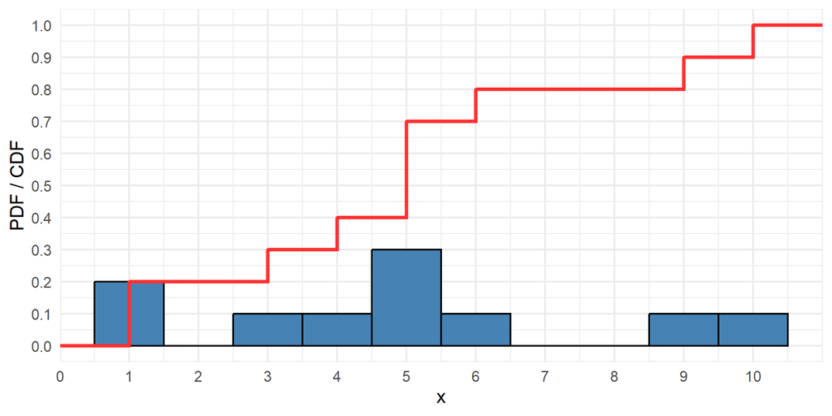